<!DOCTYPE html>

# Ridge Plots

An extended example of faceting with data summaries.

Kris Sankaran true

12-30-2022

*[Reading](https://rafalab.github.io/dsbook/gapminder.html), [Recording](https://mediaspace.wisc.edu/media/1_9kea0t1o), [Rmarkdown](https://raw.githubusercontent.com/krisrs1128/stat479/master/_posts/2021-01-20-week2-4/week2-4.Rmd)*

Ridge plots are a special case of small multiples that are particularly suited to displaying multiple parallel time series or densities.

```r
library(tidyverse)
library(dslabs)
library(ggridges)
theme_set(theme_bw())
```

An example ridge plot for the gapminder dataset is shown below. The effectiveness of this plot comes from the fact that multiple densities can be displayed in close proximity to one another, making it possible to facet across many variables in a space-efficient way.

```r
data(gapminder)
gapminder <- gapminder %>%
  mutate(
    dollars_per_day = (gdp / population) / 365,
    group = case_when(
      region %in% c("Western Europe", "Northern Europe","Southern Europe",  "Northern America",  "Australia and New Zealand") ~ "West",
      region %in% c("Eastern Asia", "South-Eastern Asia") ~ "East Asia",
      region %in% c("Caribbean", "Central America",  "South America") ~ "Latin America",
      continent == "Africa" &  region != "Northern Africa" ~ "Sub-Saharan",
      TRUE ~ "Others"
    ),
    group = factor(group, levels = c("Others", "Latin America",  "East Asia", "Sub-Saharan", "West")),
    west = ifelse(group == "West", "West", "Developing")
  )
```

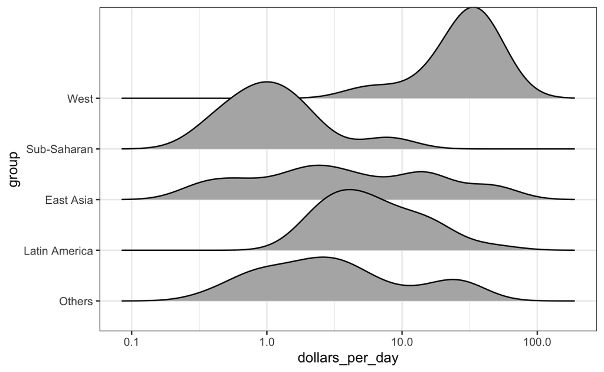

```r
past_year <- 1970
gapminder_subset <- gapminder %>%
  filter(year == past_year, !is.na(dollars_per_day))

ggplot(gapminder_subset, aes(dollars_per_day, group)) +
  geom_density_ridges() +
  scale_x_log10()
```

You might wonder, why not plot the raw data? We do this using a `geom_point` below. The result isn’t as satisfying, because, while the shape of the ridges popped out immediately in the original plot, we have to invest a bit more effort to understand the regions of higher density in the raw data plot. Also, when there are many samples, the entire range might appeared covered in marks when in fact there are some intervals with higher density than others.

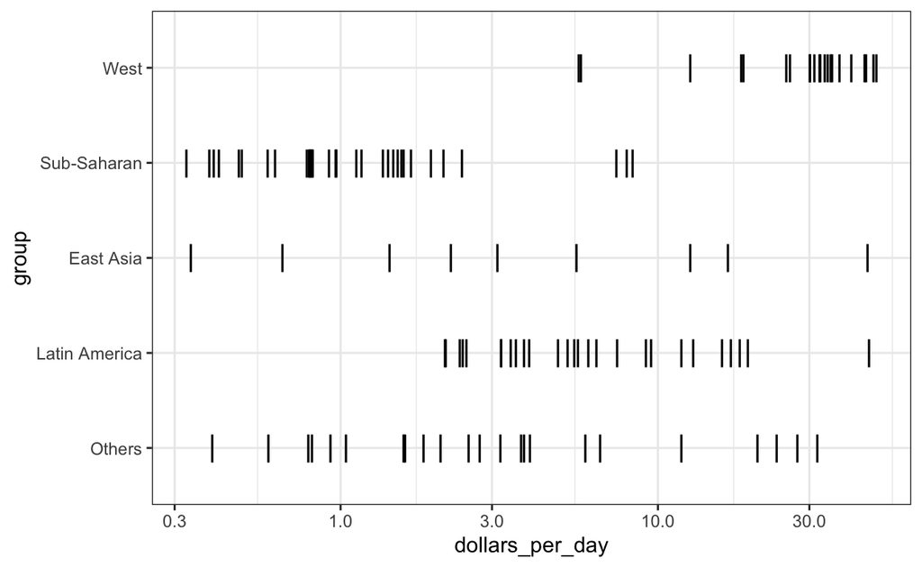

```r
ggplot(gapminder_subset, aes(dollars_per_day, group)) +
  geom_point(shape = "|", size = 5) +
  scale_x_log10()
```

A nice compromise is to include both the raw positions and the smoothed densities.

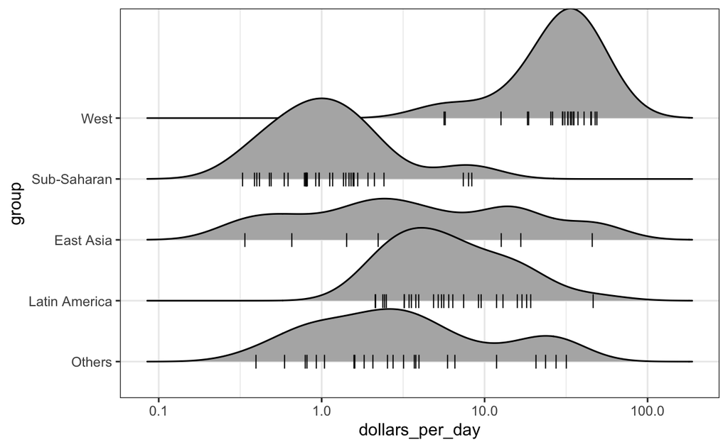

```r
ggplot(gapminder_subset, aes(dollars_per_day, group)) +
  geom_density_ridges(
    jittered_points = TRUE,
    position = position_points_jitter(height = 0),
    point_shape = '|', point_size = 3
  ) +
  scale_x_log10()
```

To exercise our knowledge of both faceting and ridge plots, let’s study a particular question in depth: How did the gap between rich and poor countries change between 1970 and 2010?

A first reasonable plot is to facet year and development status. While the rich countries have become slightly richer, there is a larger shift in the incomes for the poorer countries.

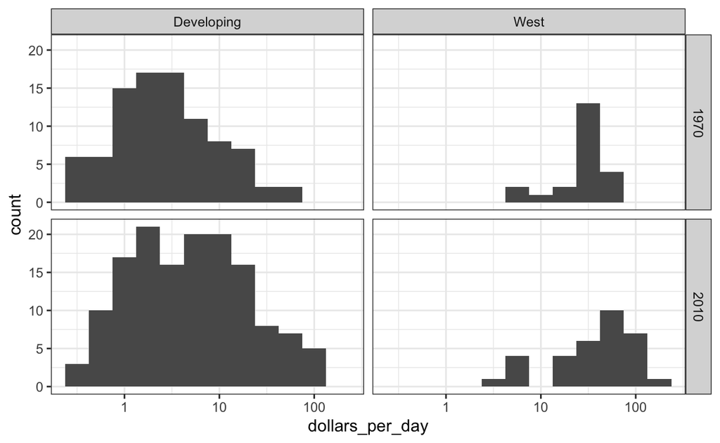

```r
past_year <- 1970
present_year <- 2010
years <- c(past_year, present_year)

gapminder_subset <- gapminder %>%
  filter(year %in% years, !is.na(dollars_per_day))

ggplot(gapminder_subset, aes(dollars_per_day)) +
  geom_histogram(binwidth = 0.25) +
  scale_x_log10() +
  facet_grid(year ~ west)
```

We can express this message more compactly by overlaying densities, but the attempt below is misleading, because it gives the same total area to both groups of countries. This doesn’t make sense, considering there are more than 4 times as many developing vs. western countries (87 vs. 21).

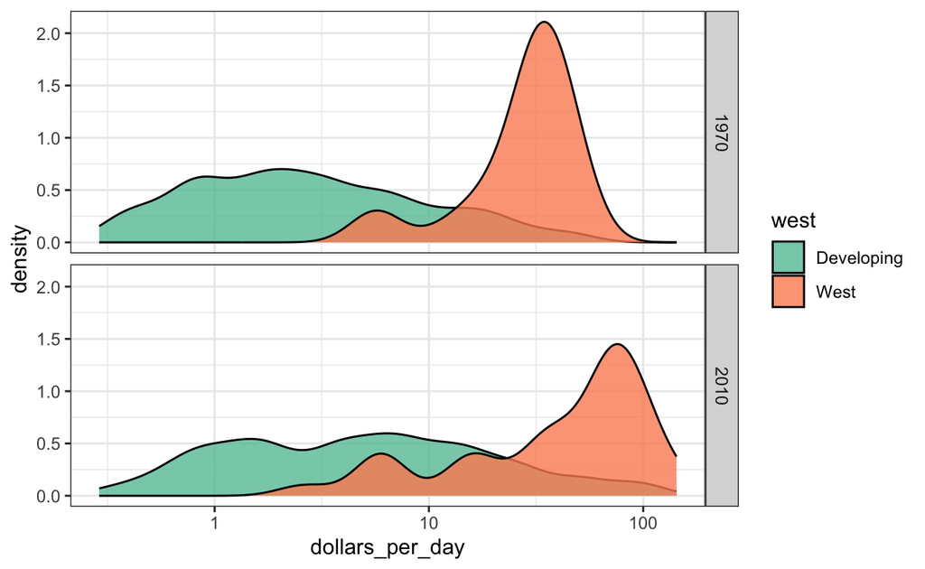

```r
ggplot(gapminder_subset, aes(dollars_per_day, fill = west)) +
  geom_density(alpha = 0.8, bw = 0.12) +
  scale_x_log10() +
  scale_fill_brewer(palette = "Set2") +
  facet_grid(year ~ .)
```

We can adjust the areas of the curves by directly referencing the `..count` variable, which is implicitly computed by ggplot2 while it’s computing these densities.

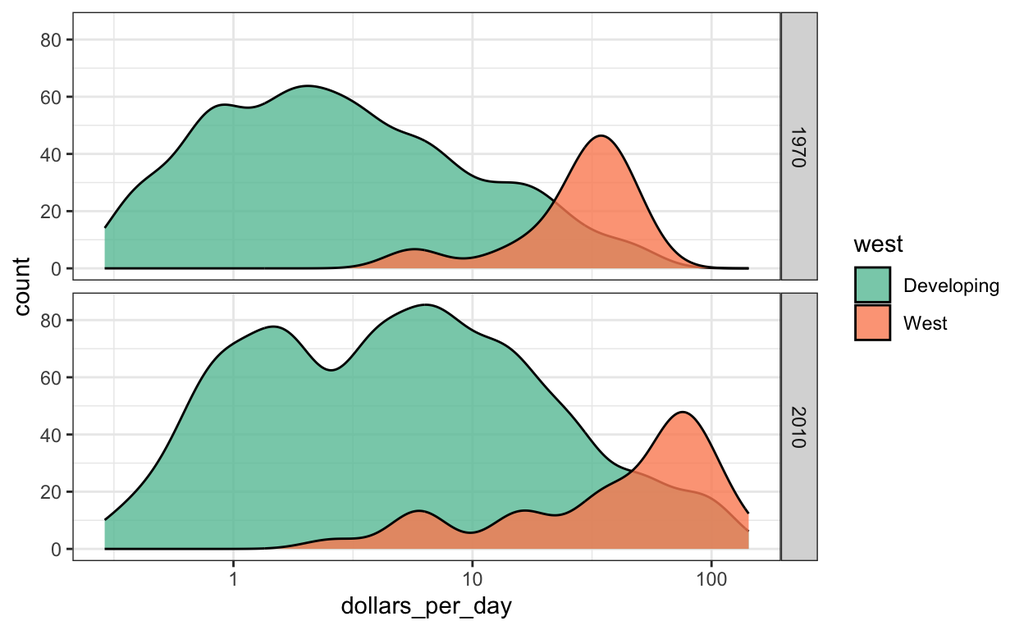

```r
ggplot(gapminder_subset, aes(dollars_per_day, y = ..count.., fill = west)) +
  geom_density(alpha = 0.8, bw = 0.12) +
  scale_x_log10() +
  scale_fill_brewer(palette = "Set2") +
  facet_grid(year ~ .)
```

Can we attribute the changes to specific regions? Let’s apply our knowledge of ridge plots.

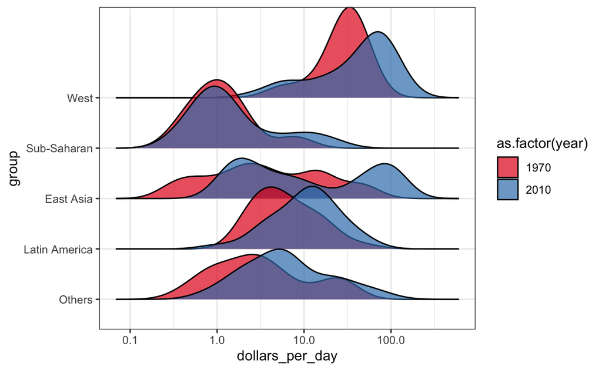

```r
ggplot(gapminder_subset, aes(dollars_per_day, y = group, fill = as.factor(year))) +
  geom_density_ridges(alpha = 0.7) +
  scale_fill_brewer(palette = "Set1") +
  scale_x_log10()
```

Alternatively, we can overlay densities from the different regions. Both plots suggest that much of the increase in incomes can be attributed to countries in Latin America and East Asia.

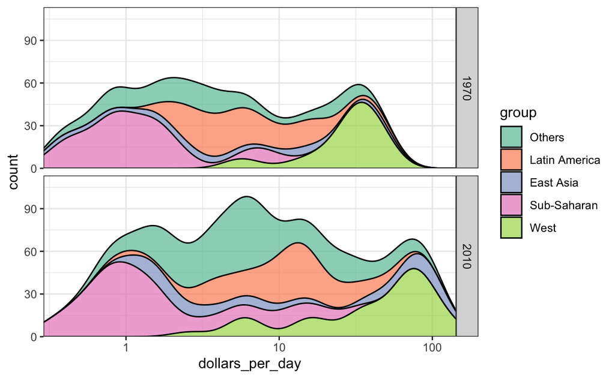

```r
ggplot(gapminder_subset, aes(dollars_per_day, fill = group, y = ..count..)) +
  geom_density(alpha = 0.7, bw = .12, position = "stack") +
  scale_fill_brewer(palette = "Set2") +
  scale_x_log10(expand = c(0, 0)) +
  scale_y_continuous(expand = c(0, 0, 0.15, 0)) +
  facet_grid(year ~ .)
```